# Examining the factors that influence Depression

#### 1 INTRODUCTION

Depression is a very common condition which affects 1in 10 people at any one time 450000 people alone in Ireland this stats is read from the internet. It can vary from mild to severe and can have an impact on little aspects of an individual also and we can say visa versa for depression as many small factors can also lead us getting into it. stats say that depression can be caused by factors sad, anxious, guilty, low energy, fatigued, any change to a normal sleep pattern, poor concentration, loss of interest in hobbies, family or social life, low self-esteem, physical aches, loss of interest in living. for my model I am finding which all factors have an effect on depression the factors that we are considering are anxiety, sleepy and other sensation scales, do you have a problem with your sleep, medication help we are taking these factors as they are related to the reasons we previously saw in the real stats as if a person is having anxiety he/she is likely to have mild t severe depression similarly to a person if we consider sleepy or other sensation scales he/she can have depression if those scales have low value. while considering a problem with sleep it can also help in getting to us as a symptom of depression and if a person is taking medication to sleep they can also become one of the factors for depression So for prediction of depression, we made the 3 models and their hypothesis ### Hypotheses

The particular hypotheses to be investigated are:

## Hypothesis 1:

H0: There will be no significant prediction of depression by sleepy and other sensation scale & have a problem with sleep. H1: There will be a significant prediction of depression by sleepy and other sensation scale & have a problem with sleep.

## Hypothesis 2:

H0: There will be no significant prediction of depression by sleepy and other sensation scale & have a problem with sleep & anxiety H1: There will be a significant prediction of depression by sleepy and other sensation scale & have a problem with sleep & anxiety.

## Hypothesis 3:

H0: There will be no significant prediction of depression by sleepy and other sensation scale & have a problem with sleep & anxiety & medication help. H1: There will be a significant prediction of depression by sleepy and other sensation scale & have a problem with sleep & anxiety & medication help.

```r
library(rmarkdown)
library(dplyr)
```

```r
library(ggplot2)
library(psych)
library(pastecs)
library(semTools)
library(car)
library(effsize)
library(lm.beta)
library(stargazer)
library(userfriendlyscience)
library(MASS)
library(ppcor)
library(olsrr)
library(pander)
sleep <- read.csv('sleep5ED.csv', header = TRUE, sep = ",")
#View(sleep)
```

#### METHADOLOGY

we have read the dataset in the R considered my variable of interest and put all of them in a myData variable . for the missing value we are getting here some missing values but I have made a new dataset when all my variables are chooses and the then removed na values from that data frame .for one just took the variables and performed test on them.

```r
myData<-"
 Concept                                  | Variable Name    | Statistical Type      | Possible Values
   HADS Anxiety                                  |anxiety            |scale              |Total HADS Anxiety score (range from 0=no anxiety to 21=severe anxiety)
sleepy and other sensation scale                  | totsas            |scale              |Total Sleepiness and associated
sensation scale score (5=low, 50=extreme sleepiness)
   HADS Depression                                |depress            |scale              |range from 0=no depression to 21=severe depression
 Do you have problem with your sleep              |problem            |Nominal            |1=yes 2=no
Medication help                                   |medhelp            |Nominal            |1=yes 2=no"


df <- read.delim(textConnection(myData),header=FALSE,sep="|",strip.white=TRUE,stringsAsFactors=FALSE)
names(df) <- unname(as.list(df[1,])) # headers
df <- df[-1,] # remove first row
row.names(df)<-NULL
pander(df, style = 'rmarkdown')
```

Table continues below

[output not shown]

Table continues below

| Statistical Type |
| --- |
| scale |
| scale |
| scale |
| Nominal |
| Nominal |

| Possible Values |
| --- |
| Total HADS Anxiety score (range from 0=no anxiety to 21=severe anxiety) |
| Total Sleepiness and associated |
| range from 0=no depression to 21=severe depression |
| 1=yes 2=no |
| 1=yes 2=no |

#### DATASET

variable that are considered and modified ##1. Level of anxiety

```r
pastecs::stat.desc(sleep$anxiety, basic=F)
```

```
##       median         mean      SE.mean CI.mean.0.95          var
##    6.0000000    6.3358209    0.2133066    0.4199769   12.1939181
##      std.dev     coef.var
##    3.4919791    0.5511486
```

```r
#skewness and kurtosis
anskew<-semTools::skew(sleep$anxiety)
ankurt<-semTools::kurtosis(sleep$anxiety)
anskew
```

```
##    skew (g1)           se            z            p
## 0.5485320493 0.1496264004 3.6660111299 0.0002463632
```

```r
ankurt
```

```
## Excess Kur (g2)              se               z               p
##     -0.03911663      0.29925280     -0.13071434      0.89600128
```

```r
#We divide the skew statistic by the standard error to get the standardised score
stdskew1<-anskew[1]/anskew[2]
stdkurt1<-ankurt[1]/ankurt[2]
stdkurt1
```

```
## Excess Kur (g2)
##      -0.1307143
```

```r
stdskew1
```

```
## skew (g1)
##  3.666011
```

```r
outliers <- sleep %>%
  filter(scale(anxiety) >3.29 | scale(anxiety) < -3.29)
outliers
```

```
##  [1] ï..id        sex          age          marital      edlevel
##  [6] weight       height       healthrate   fitrate      weightrate
## [11] smoke        smokenum     alchohol     caffeine     hourwnit
## [16] hourwend     hourneed     trubslep     trubstay     wakenite
## [21] niteshft     liteslp      refreshd     satsleep     qualslp
## [26] stressmo     medhelp      problem      impact1      impact2
## [31] impact3      impact4      impact5      impact6      impact7
## [36] stopb        restlss      drvsleep     drvresul     ess
## [41] anxiety      depress      fatigue      lethargy     tired
## [46] sleepy       energy       stayslprec   getsleprec   qualsleeprec
## [51] totsas       cigsgp3      agegp3       probsleeprec drvslprec
## <0 rows> (or 0-length row.names)
```

```r
#count them using dplyr summarize
numoutliers<-outliers %>%
  summarize(count=n())
fullcount<-sleep %>%
  summarize(count=n())
numoutliers
```

```
##   count
## 1     0
```

```r
fullcount
```

```
##   count
## 1   271
```

## Report of normality analysis

The first variable is a HADS Anxiety taken as the level of anxiety which is a scalar variable which is taken as a predictor to predict the variable to be predicted .for this predictor we have to check for normality. To do that firstly stat.desc the anxiety and finding its skewness and kurtosis by using semtools, to make the values into standardised value, remove the error by stdskew<-skew[1]/skew[2] & stdkurt <-kurt[1]/kurt[2].For anxiety the values are 3.66 & -0.13 respectively kurtosis is within the limit but stdskew is not in between -2 to 2 by this anxiety cannot be said as normal.by this can’t say that this is not parametric .we tried to find outliers but could not be found any outliers,standardised scores were inside the acceptable range of +/3.29. level of anxiety will, therefore, be treated as a not normal within this analysis. we can see non-normality by ggplot (histogram) and the QQ plot from plots given below(figure 1: Level of anxiety & figure 2: QQPlot or level of anxiety).

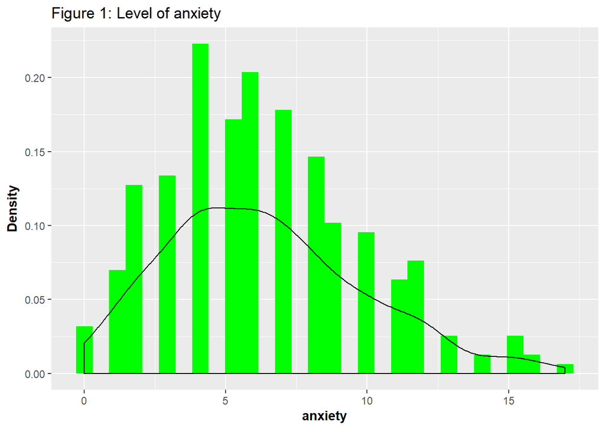

```r
#create a histogram showing skewness and kurtosis
ggplot(sleep, aes(y = ..density.., x = anxiety)) +
  geom_histogram(fill = 'green') +
  geom_density(colour = 'black') + xlab(expression(bold('anxiety'))) +
  ylab(expression(bold('Density')))+ggtitle('Figure 1: Level of anxiety')
```

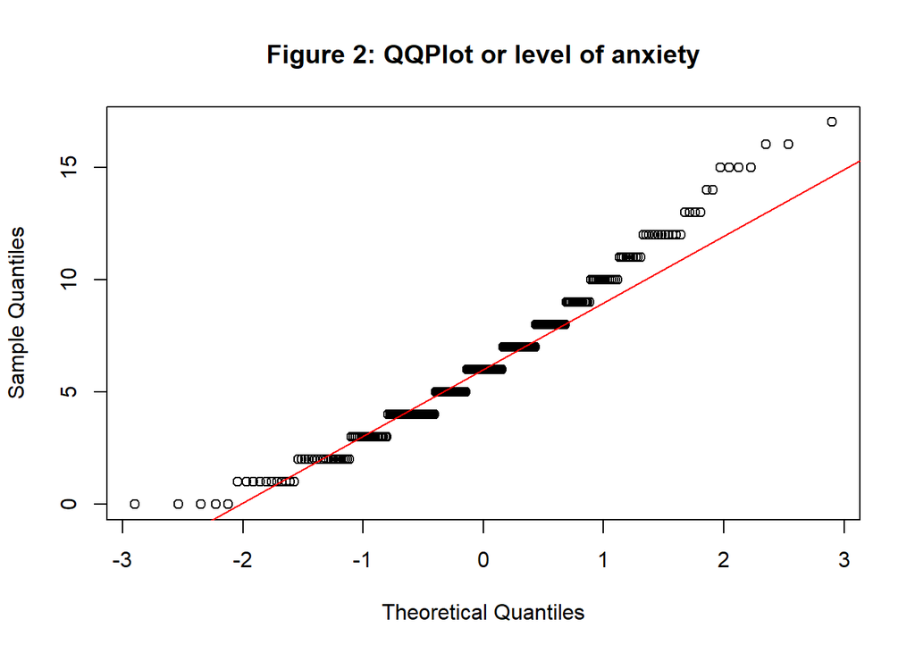

```r
#Create a qqplot
qqnorm(sleep$anxiety,  main="Figure 2: QQPlot or level of anxiety")
qqline(sleep$anxiety, col=2)
```

## 2. sleepy and other sensation scale

```r
pastecs::stat.desc(sleep$totsas, basic=F)
```

```
##       median         mean      SE.mean CI.mean.0.95          var
##   27.0000000   26.0438247    0.6640035    1.3077539  110.6660717
##      std.dev     coef.var
##   10.5197943    0.4039266
```

```r
#skewness and kurtosis
tsskew<-semTools::skew(sleep$totsas)
tskurt<-semTools::kurtosis(sleep$totsas)
tsskew
```

```
##   skew (g1)          se           z           p
## -0.05669872  0.15461042 -0.36671994  0.71382793
```

```r
tskurt
```

```
## Excess Kur (g2)              se               z               p
##    -1.130091496     0.309220843    -3.654642050     0.000257541
```

```r
#We divide the skew statistic by the standard error to get the standardised score
stdskew2<-tsskew[1]/tsskew[2]
stdkurt2<-tskurt[1]/tskurt[2]
stdkurt2
```

```
## Excess Kur (g2)
##       -3.654642
```

```r
stdskew2
```

```
##  skew (g1)
## -0.3667199
```

```r
outliers <- sleep %>%
  filter(scale(totsas) >3.29 | scale(totsas) < -3.29)
outliers
```

```
##  [1] ï..id        sex          age          marital      edlevel
##  [6] weight       height       healthrate   fitrate      weightrate
## [11] smoke        smokenum     alchohol     caffeine     hourwnit
## [16] hourwend     hourneed     trubslep     trubstay     wakenite
## [21] niteshft     liteslp      refreshd     satsleep     qualslp
## [26] stressmo     medhelp      problem      impact1      impact2
## [31] impact3      impact4      impact5      impact6      impact7
## [36] stopb        restlss      drvsleep     drvresul     ess
## [41] anxiety      depress      fatigue      lethargy     tired
## [46] sleepy       energy       stayslprec   getsleprec   qualsleeprec
## [51] totsas       cigsgp3      agegp3       probsleeprec drvslprec
## <0 rows> (or 0-length row.names)
```

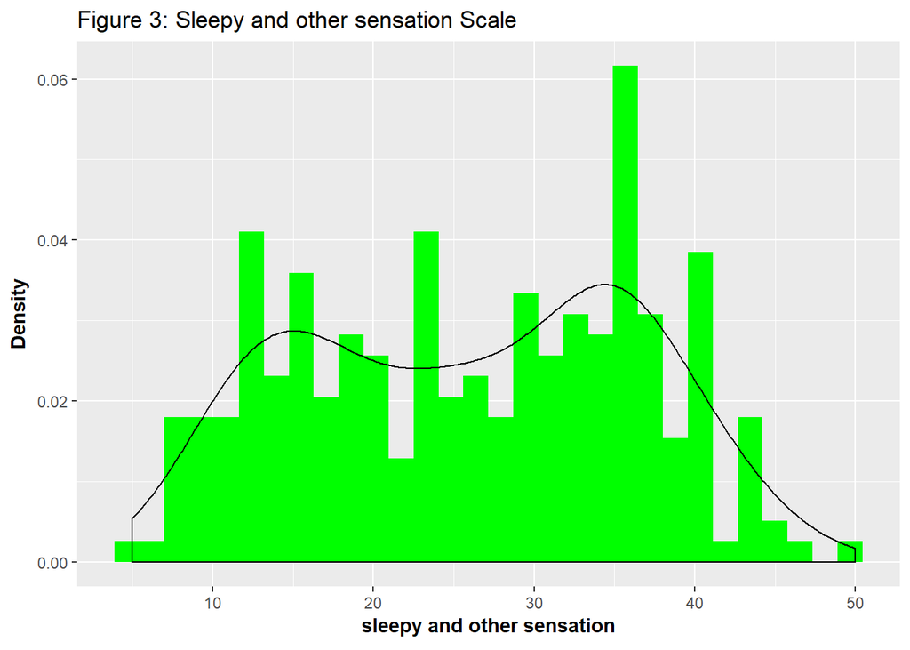

```r
#create a histogram showing skewness and  kurtosis
ggplot(sleep, aes(y = ..density.., x = totsas)) +
  geom_histogram(fill = 'green') +
  geom_density(colour = 'black') + xlab(expression(bold('sleepy and other sensation'))) +
  ylab(expression(bold('Density')))+ggtitle('Figure 3: Sleepy and other sensation Scale')
```

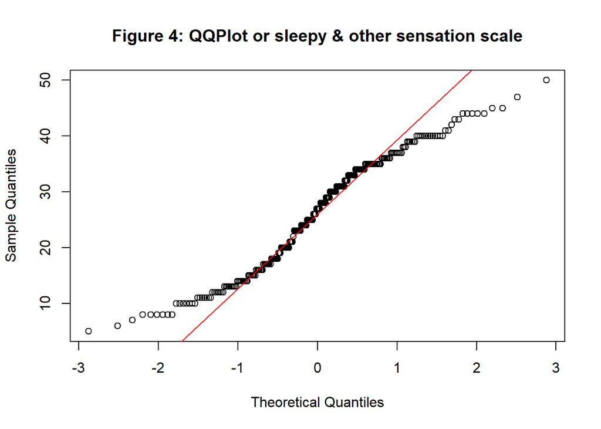

```r
#Create a qqplot
qqnorm(sleep$totsas,  main="Figure 4: QQPlot or sleepy & other sensation scale")
qqline(sleep$totsas, col=2)
```

```r
pastecs::stat.desc(sleep$depress, basic=F)
```

```
##       median         mean      SE.mean CI.mean.0.95          var
##    3.0000000    3.4981413    0.1825051    0.3593262    8.9598846
##      std.dev     coef.var
##    2.9933066    0.8556849
```

```r
#skewness and kurtosis
dpskew<-semTools::skew(sleep$depress)
dpkurt<-semTools::kurtosis(sleep$depress)
dpskew
```

```
##    skew (g1)           se            z            p
## 9.517860e-01 1.493480e-01 6.372940e+00 1.854383e-10
```

```r
dpkurt
```

```
## Excess Kur (g2)              se               z               p
##       0.1076964       0.2986961       0.3605551       0.7184320
```

```r
#We divide the skew statistic by the standard error to get the standardised score
stdskew2<-dpskew[1]/dpskew[2]
stdkurt2<-dpkurt[1]/dpkurt[2]
stdkurt2
```

```
## Excess Kur (g2)
##       0.3605551
```

```r
stdskew2
```

```
## skew (g1)
##   6.37294
```

```r
outliers <- sleep %>%
  filter(scale(depress) >3.29 | scale(depress) < -3.29)
outliers
```

```
##  [1] ï..id        sex          age          marital      edlevel
##  [6] weight       height       healthrate   fitrate      weightrate
## [11] smoke        smokenum     alchohol     caffeine     hourwnit
## [16] hourwend     hourneed     trubslep     trubstay     wakenite
## [21] niteshft     liteslp      refreshd     satsleep     qualslp
## [26] stressmo     medhelp      problem      impact1      impact2
## [31] impact3      impact4      impact5      impact6      impact7
## [36] stopb        restlss      drvsleep     drvresul     ess
## [41] anxiety      depress      fatigue      lethargy     tired
## [46] sleepy       energy       stayslprec   getsleprec   qualsleeprec
## [51] totsas       cigsgp3      agegp3       probsleeprec drvslprec
## <0 rows> (or 0-length row.names)
```

```r
#count them using dplyr summarize
numoutliers<-outliers %>%
  summarize(count=n())
fullcount<-sleep %>%
  summarize(count=n())
numoutliers
```

```
##   count
## 1     0
```

```r
fullcount
```

```
##   count
## 1   271
```

```r
#perform square root transform
newDepress<-sqrt(sleep$depress)
newDepress
```

```
##   [1] 1.000000 1.414214 3.162278 1.732051 0.000000 2.449490 3.162278
##   [8] 3.316625 3.316625 0.000000 2.000000 0.000000 1.732051 3.464102
##  [15] 0.000000 1.414214 0.000000 1.732051 1.000000 2.645751 2.236068
##  [22] 2.236068 3.162278 2.000000 1.414214 2.645751 1.732051 1.000000
##  [29] 1.000000 2.828427 1.000000 0.000000 1.732051 2.000000 1.000000
##  [36] 1.414214 1.000000 1.414214 3.162278 1.000000 2.828427 1.000000
##  [43] 1.000000 0.000000 1.000000 1.732051 1.000000 2.236068 2.000000
##  [50] 1.000000 1.000000       NA 1.414214 1.732051 2.236068 3.000000
##  [57] 0.000000 2.236068 2.236068 1.732051 2.000000 2.000000 1.414214
##  [64] 2.000000 1.000000 1.414214 2.000000 2.236068 1.732051 0.000000
##  [71] 1.414214 1.000000 1.000000 0.000000 1.000000 3.162278 2.645751
##  [78] 1.000000 2.000000 1.732051 0.000000 1.414214 2.236068 1.000000
##  [85] 1.414214 1.000000 1.000000 0.000000 0.000000 0.000000 1.414214
##  [92] 1.000000 1.732051 1.414214 1.414214 1.732051 2.645751 2.000000
##  [99] 1.000000 1.000000 3.000000 1.000000 1.414214 1.000000 1.414214
```

[output cut: 24 more lines]

```r
#skew&kurt for new transformed depress
newDepress_skew<-semTools::skew(newDepress)
newDepress_kurt<-semTools::kurtosis(newDepress)
newDepress_skew
```

```
##  skew (g1)         se          z          p
## -0.1590907  0.1493480 -1.0652350  0.2867696
```

```r
newDepress_kurt
```

```
## Excess Kur (g2)              se               z               p
##     -0.50321320      0.29869605     -1.68469986      0.09204649
```

```r
#standadised skewness and kurtosis value
newDepress_stdskew2<-newDepress_skew[1]/newDepress_skew[2]
newDepress_stdkurt2<-newDepress_kurt[1]/newDepress_kurt[2]
newDepress_stdkurt2
```

```
## Excess Kur (g2)
##         -1.6847
```

```r
newDepress_stdskew2
```

```
## skew (g1)
## -1.065235
```

```r
#calculating outliers
newDepress_<- scale(newDepress)
outliers=0
for(i in 1: length(newDepress_))
    {
if(!is.na(newDepress_[i]))
   {
if(newDepress_[i]>3.29|newDepress_[i]<3.29)
{
  outliers=outliers+1
}
    }
    }
fullcount<-length(newDepress_)
outliers
```

```
## [1] 269
```

```r
fullcount
```

```
## [1] 271
```

## Report of normality analysis

The third variable is an HDAS Depression taken as Level of Depression which is a scalar variable which is taken as a scale to be predicted in the multiple regression by the 4 other variable 2 scaler and other 2 categorical .for this response variable we have to check for normality. To do that firstly stat.desc the depress variable which describes its mean, median, variance, std and finding its skewness and kurtosis by using semtools, to make the values into standardised value, remove the error by stdskew<-skew[1]/skew[2] & stdkurt <-kurt[1]/kurt[2] .For Level of depression, the values are 6.372 & 0.360 respectively kurtosis is within the limit but stdskew is not in between -2 to 2 limits, by this depress can be said as not normal. we tried to find outliers but could not be found any outliers, standardised scores were inside the acceptable range of +/3.29.

As it is the response variable I tried to transform it and tried to turn it to normal.For transformation sqrt(depress)is conducted and save it to a new variable i.e newDepress while performing skewness and kurtosis the get new values, after finding stdskew & stdkurt i.e-1.065 & -1.684 these both the values are in the limit of -2 & 2 so this newDepress can be said as normal and we can take this new variable as the response variable which will be predicted by the predictors. Level of Depression will therefore be treated as a normal within this analysis. we can see normality by ggplot (histogram) and the QQ plot from plots given below(figure 5: Depression Level & figure 6: QQPlot or Depression level).

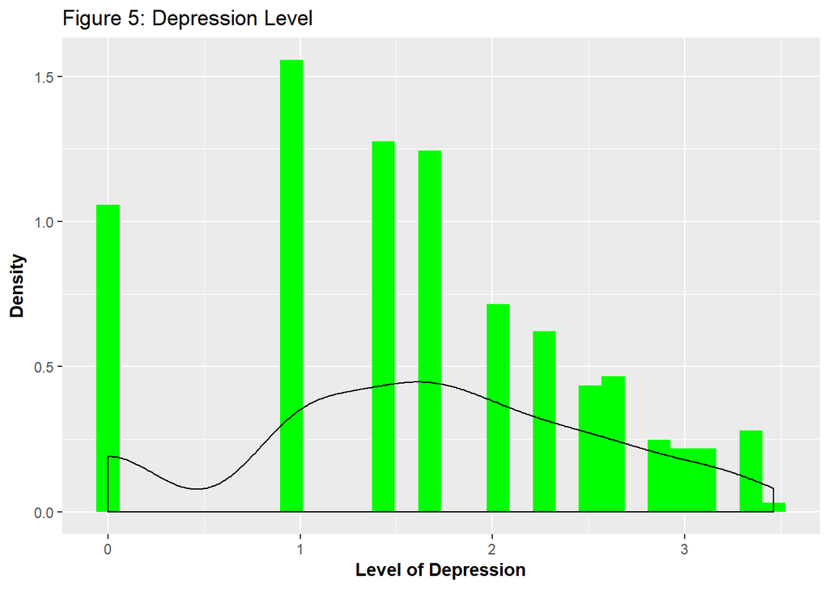

```r
ggplot( )+aes(y = ..density.., x = newDepress) +
  geom_histogram(fill = 'green') +
  geom_density(colour = 'black') + xlab(expression(bold('Level of Depression'))) +
  ylab(expression(bold('Density')))+ggtitle('Figure 5: Depression Level')
```

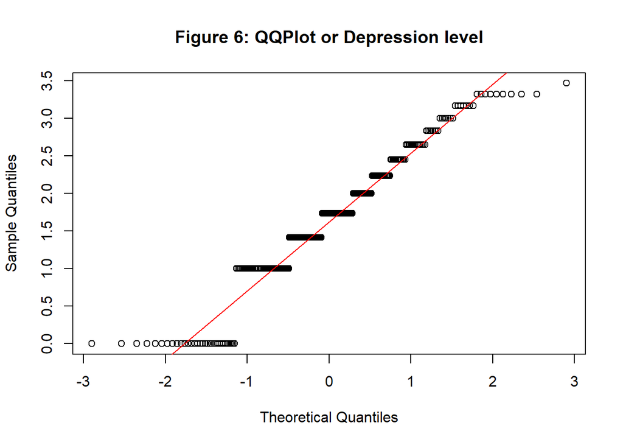

```r
#Create a qqplot
qqnorm(newDepress,  main="Figure 6: QQPlot or Depression level")
qqline(newDepress, col=2)
```

```r
table(sleep$problem)
```

```
##
##   1   2
## 117 152
```

```r
sleep_problem <- data.frame(
  group = c("yes", "no"),
  value = c(117, 152)
  )
head(sleep_problem)
```

```
##   group value
## 1   yes   117
## 2    no   152
```